# Rank Of World Universities by Hussien Ali Elsyaed

```
## [1] "C:/Users/Hussien Ali/Documents"
```

# Introduction about the dataset :

This data set is for world universities ranking. It is prepared by The Times Higher Education World University Ranking.It is available on Kaggle. It contains the rank for the years from 2011 to 2016. The number of variables in this dataset is 14 variables with 2603 rows. The description for each variable is provided in the text file attached with this one.

# Univariate Plot Section :

Here I will perform the analysis of one variable. The histogram distribution for most of variables is introduced and boxplots and frquency polygon also are used when it is more appropraite to use them.

### Countries and universities:

The number a country stated in the dataset will be plotted.Because there are 72 countries and we can not make one hisi=togram for all of these countries, so we can investigate first the countries in the rank of 2011.

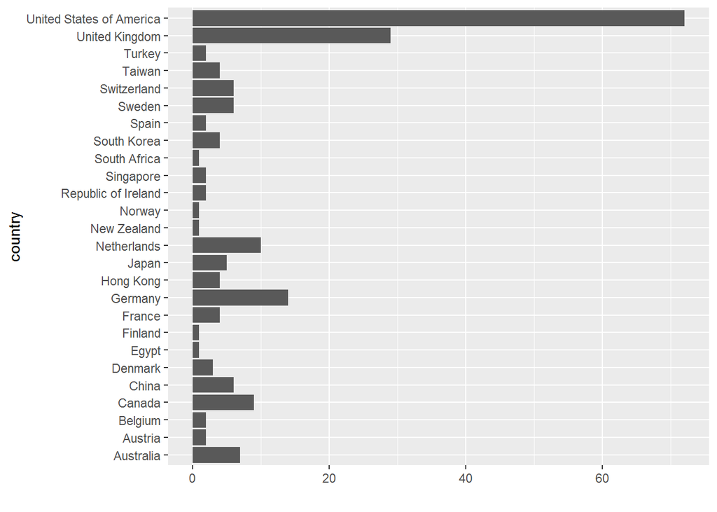

```
## <ScaleContinuousPosition>
##  Range:
##  Limits:    0 --    1
```

There are a lot of countries in this survey and a histogram will not show the information clearly.

We want to look at which countries are the dominant for the rank over the 6 years . We will plot a histogram for the 10 highest ranked universities in the 6 years.We are doing that because there are 72 countries and looking at the wole data is hard in one histogram. so we can concentrate only on the most important countries. Note : This is done after converting the world rank variable from factor to integer.

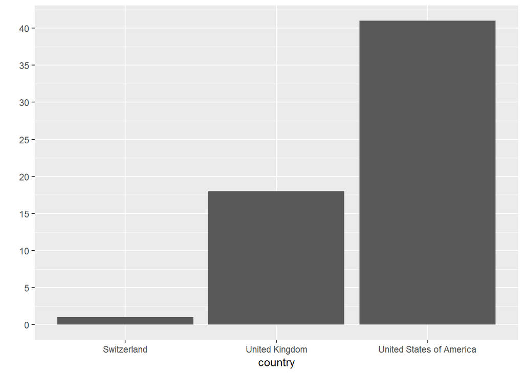

We can see that USA and Uk have the most universities in the rank of top 10 universities.

We can look at the countries in the rank in another way. This is by looking at the number that a country was stated in the survey at any rank and to limit the results, we can look at the countries stated over 100 times.

| country | n |
| --- | --- |
| Australia | 117 |
| Canada | 108 |
| Germany | 152 |
| United Kingdom | 300 |
| United States of America | 659 |

## Student-staff Ratio Variable:

Now ,we see how the histogarm of student staff ratio for all the uiniversities and then we will see this histogram but for each year individully.

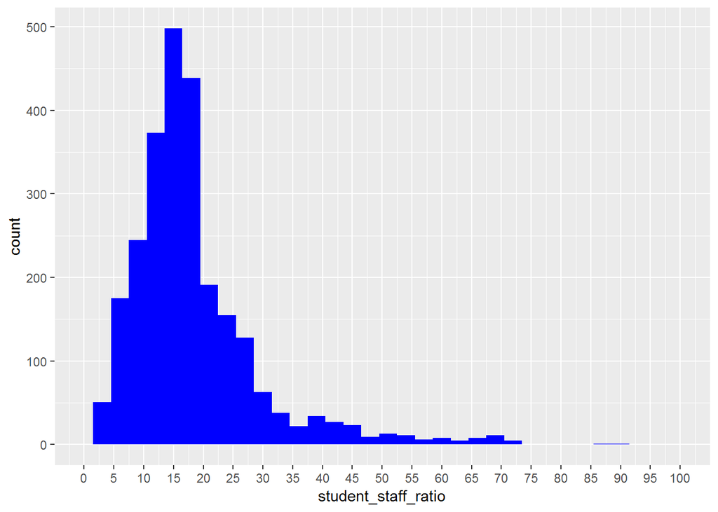

We can see that there is an outlier where the student staff ratio exceeds 80 students per one iddividual of the staff. But most of the universities have the ratio around 15 . We want to know how many universities have this ratio > 80

```
## [1] University of Mannheim           Technical University of Dortmund
## [3] Anadolu University               University of South Africa
## 818 Levels: ??cole Normale Sup??rieure ...
```

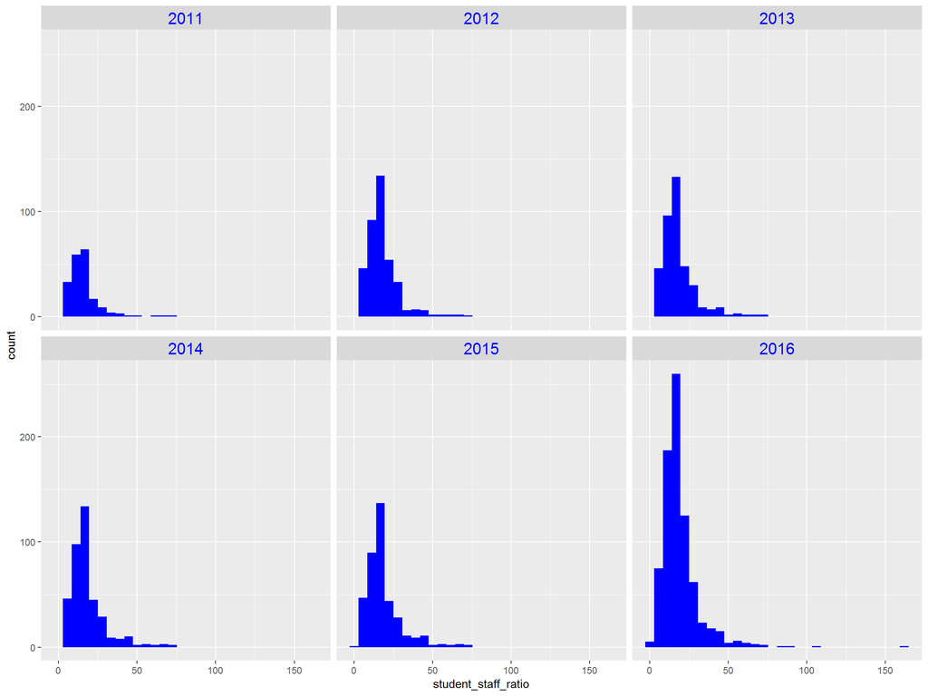

We can notice that the student staff ratio did not exceed the value of 80 except in year 2016 where the rank extended to invovle 1200 unversities but for year 2011 the ratio is very low where it only invovled the top 200 universities in the world.

## Teaching Variable :

We want to look at the teaching variable to know what is the distribution of this factor.

We will look at this factor for each country individually.

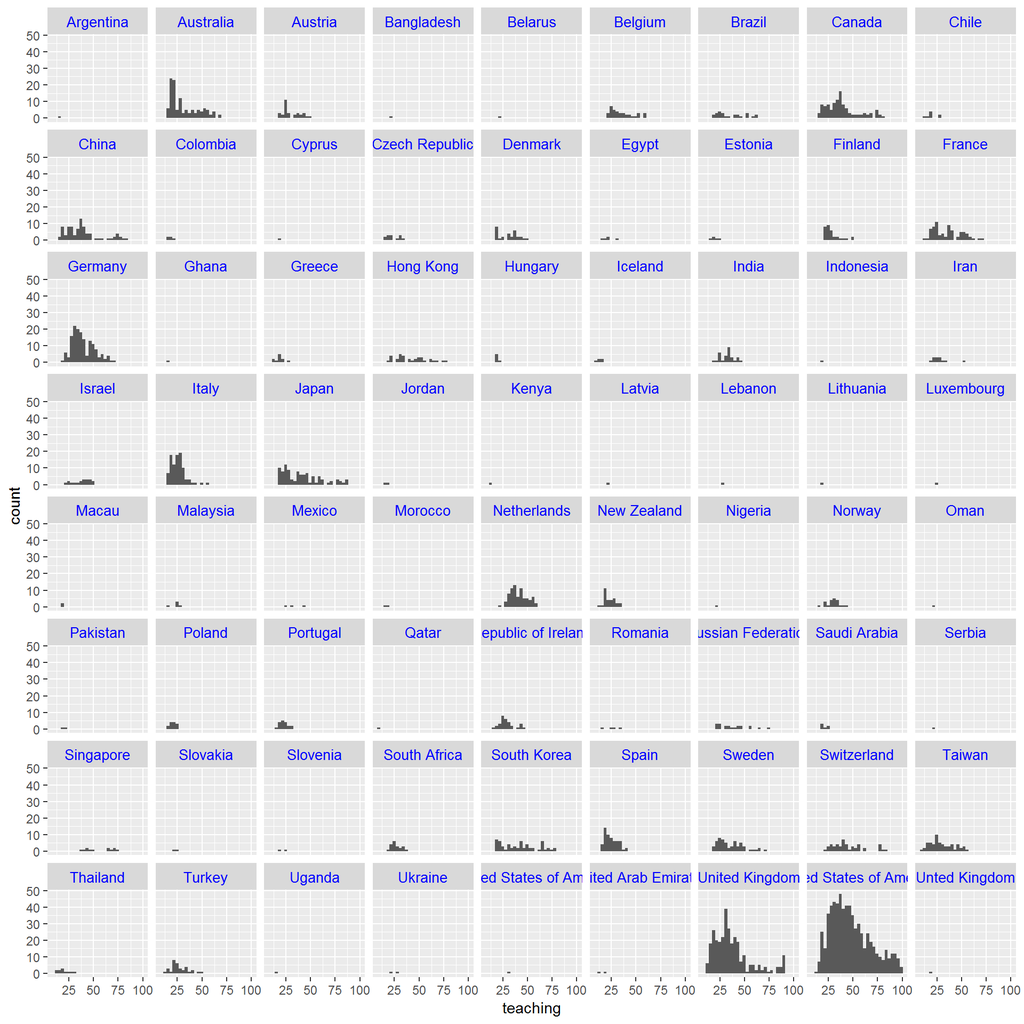

A brief look at this plot, we can say that Australia, Canada Germany,Italy,Japan , USA and UK have the highest teaching variable .

We can look similarly at the other variables. Let’s look at the research ,citation.

## Research Variable :

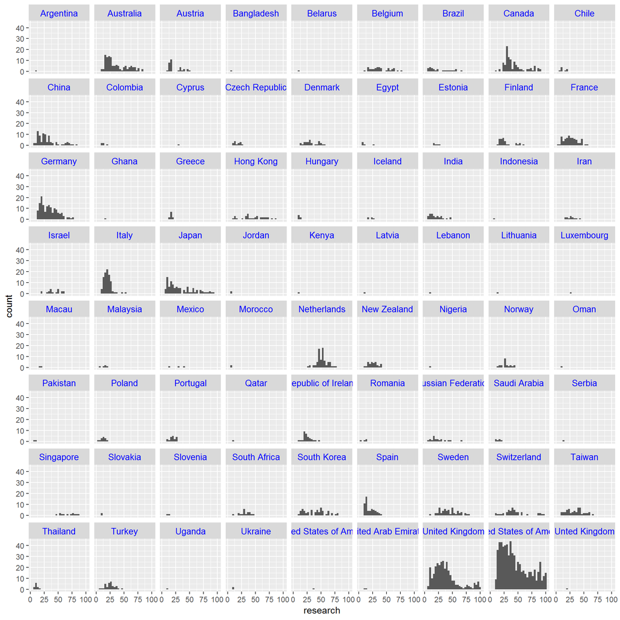

The results are almost the same like the teaching variable, and this makes sense because as the teaching staff becomes more stronger , the research variable will be higher. For better visualisation and to make comparison among countries , the square root function is applied to the y-axis.

## Citations Variable :

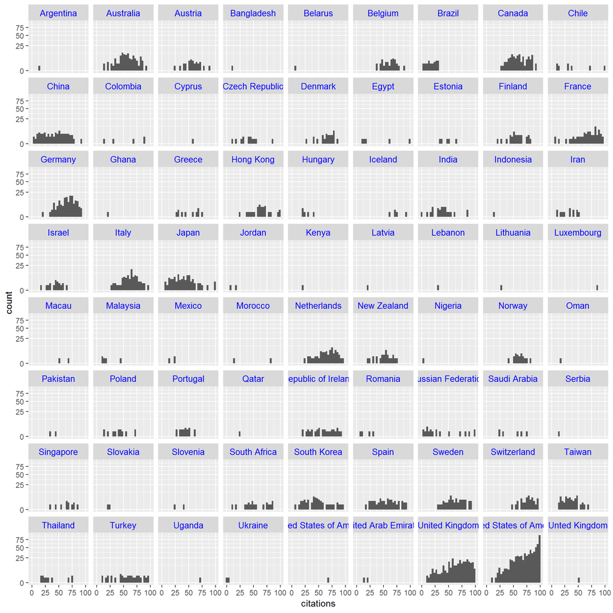

USA, UK ,Germany, Italy,Japan, Australia, Canada are the same countries.however ,we have some new countries with apparent citations like South Korea, Spain, Netherlands,Belgium ,Seweden ,Taiwan and Brazil.

## Number of Students Variable:

We want to look at the distribution of the number of students. We will look at this distribution for the whole dataset and then we will facet over each year.

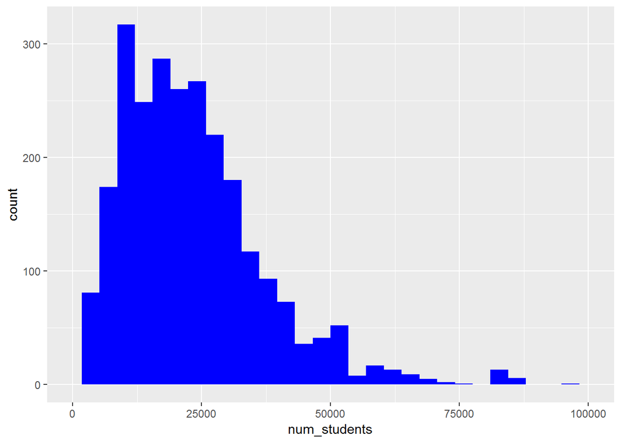

It seems that there is a variance between the number of students. so we want to facet over year because maybe these outliers are because the universities in the last order of the rank in 2016.

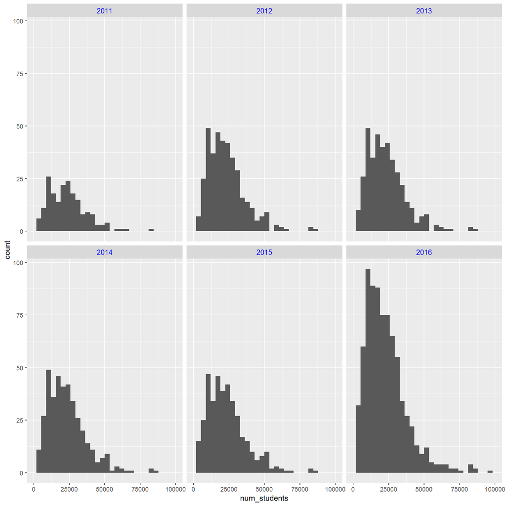

## International Students Variable

Now we can look at the distrbution of international students and this variable is expressed in this dataset as a percentage value. I think it is better that we see this distribution for each country.

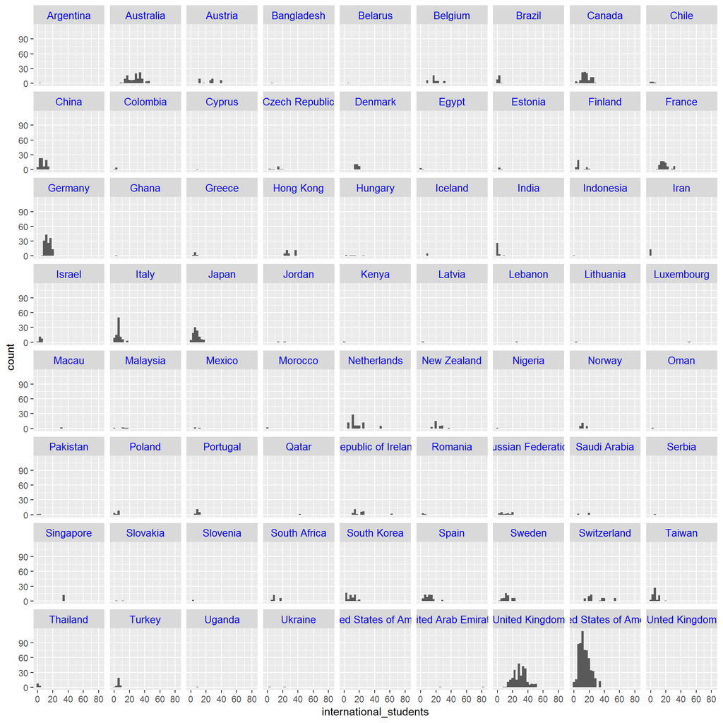

We can see that Germany,Italy, Japan ,Canada, UK and USA are highest countries with his variable . Later on in the bivariate analysis we will calculate this number and plot its distribution.

We can compare this for international students using theBox Plot because a polygon will not be very clear and we can concentrate on the highest 200 universities in the rank.

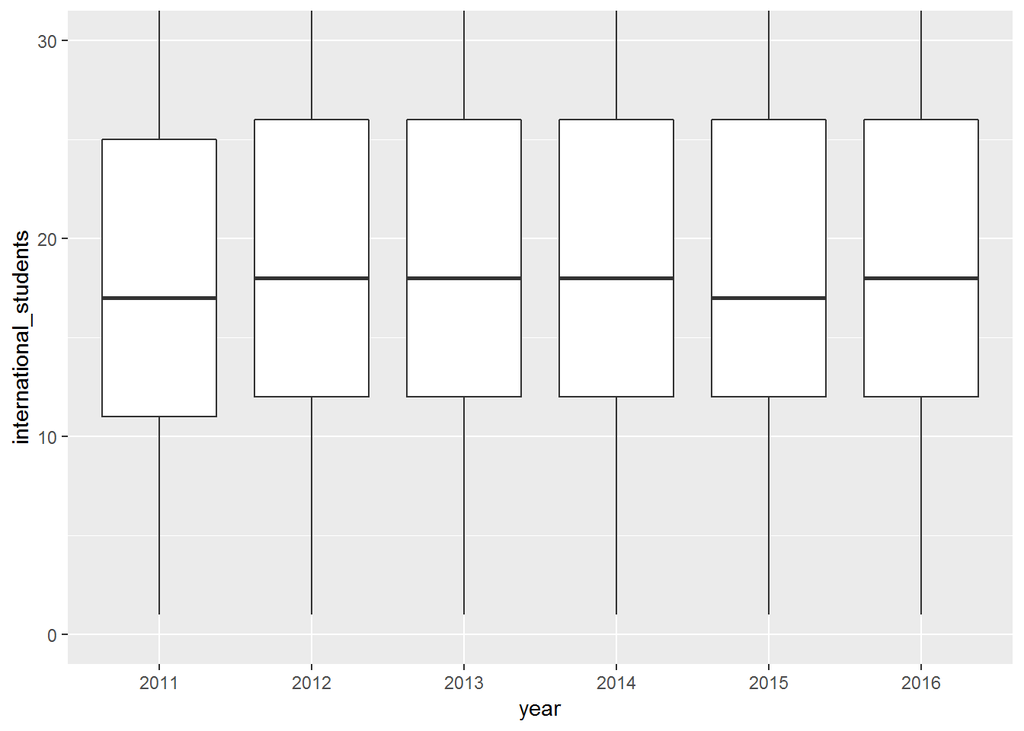

The ratio has increased in 2012 and it is almost constant since this time.

## International Variable :

Now ,we look at the variable international to see which countries are the key players and leading for this variable. This variable should be related to the reputation of the university and the country as well.

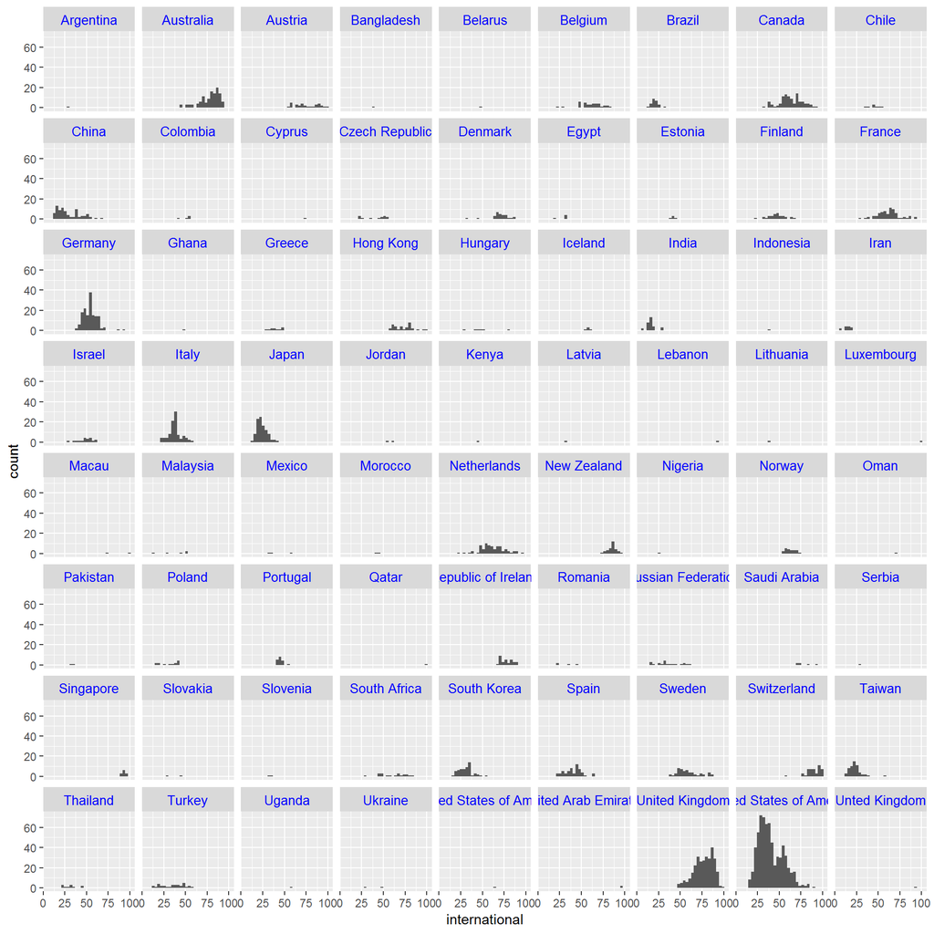

As usual Australia, Germany, Italy,Japan, UK and USA are the leading countries for this variable.Australia’s distribution is skewed means that its unversities have high international grades.

## Income Variable

We can expect that the income of the universities increase by time. So we can draw its distribution by year.First, we will draw it by year for the whole dataset and then we choose the best 200 universities in each year to make the comparison fair beacuse number of universisties for each year is different.

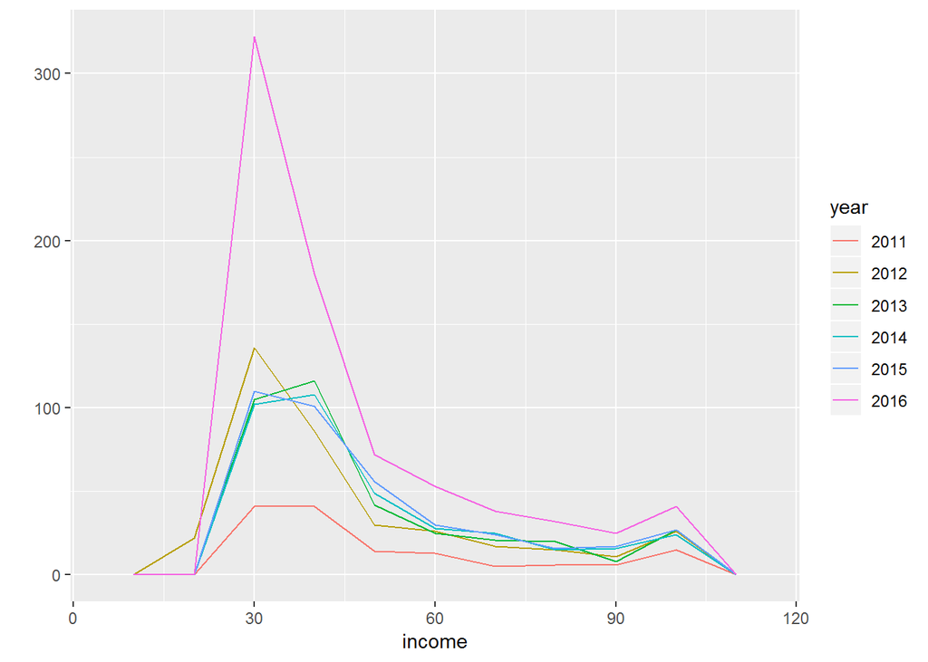

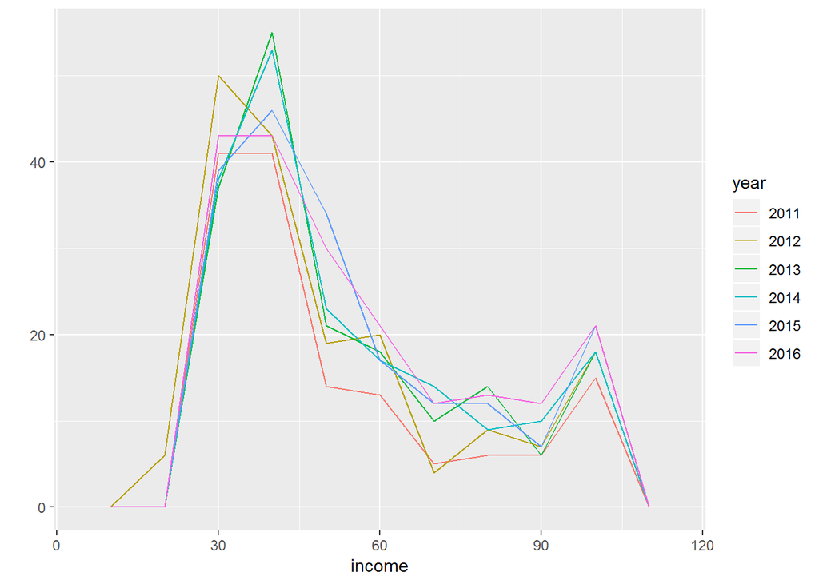

It is obvious is the comparison between 2011 and 2016 is not fair for the first graph.But as we expected the income for 2016 is almost the highest and for 2011 is the lowest.

# Univariate Analysis:

We have a dataset containing from 14 variables and 2603 rows. The main features of interest in our dataset is we have the same rank repeated for 6 consecutive years and thus will help us to see and track the change over the years like we did in the income and the ratio of international students. The dataset also has multiple variables which will help us to make a lot of analysis to get the full picture.

The distributions are almost predicted except that the citations factor had new countries with high rate. The increase in percentage of international students was expected over years. All other distributions were close.

I have a lot of operations on the data to be clean. Numbers were cleaned from commas and dashes. Factor variables then converted to integers to create nice and smooth histograms.

# Bivariate Plots Section

In the bivariate analysis I think it is better to look at the correlation between the total score variable and other variables. The total score variable is the one which decides the final order of the rank. I will choose four variables to be investigated versus total score variable. They are research, teaching, student staff ratio and income. This will help us to see what is the most variable which affects the score of the universu=ity to be higher.

## Relation between the total score and teaching:

This is investigated for the whole dataset only.

```
##
##  Pearson's product-moment correlation
##
## data:  df$teaching and df$total_score
## t = 69.226, df = 1199, p-value < 2.2e-16
## alternative hypothesis: true correlation is not equal to 0
## 95 percent confidence interval:
##  0.8824326 0.9051315
## sample estimates:
##       cor
## 0.8943562
```

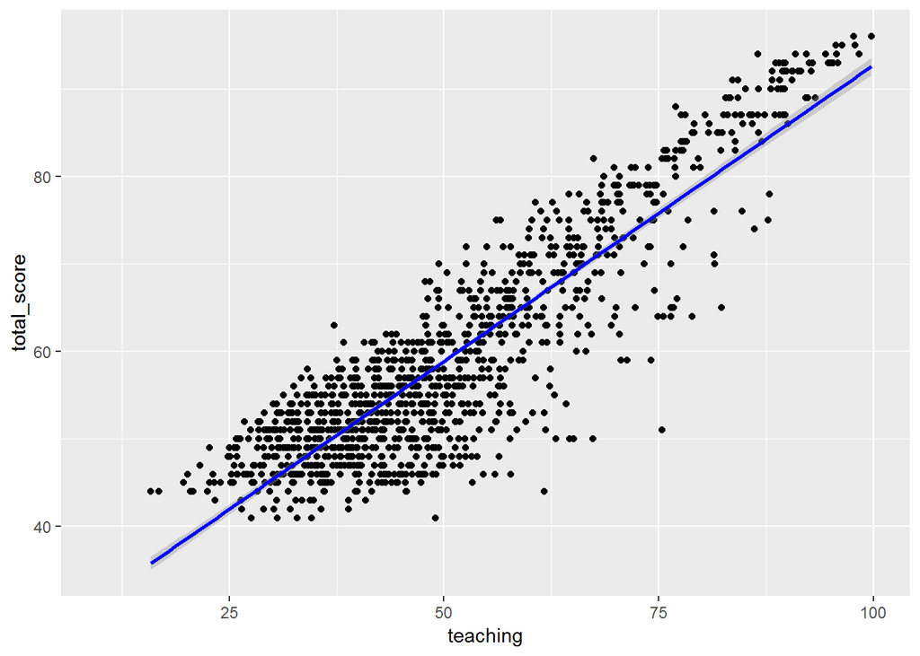

Wow ,It seems like a very nice scatter plot which indicates a high correlation factor between the two values.

We can use the function cor.test to calculate this value. The result was 0.894. The result is the same if calculated for the dataset of the top 200 universities.

## Relation between research and total score :

```
##
##  Pearson's product-moment correlation
##
## data:  df$research and df$total_score
## t = 73.183, df = 1199, p-value < 2.2e-16
## alternative hypothesis: true correlation is not equal to 0
## 95 percent confidence interval:
##  0.8930190 0.9137676
## sample estimates:
##       cor
## 0.9039237
```

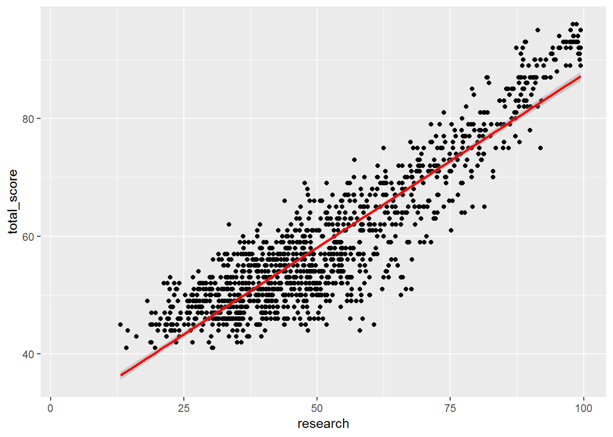

As expected the correlation between the two variables is very high. It is 0.904 from cor.test function.

## Relation between the total score and income :

```
##
##  Pearson's product-moment correlation
##
## data:  df$income and df$total_score
## t = 7.5561, df = 1059, p-value = 8.959e-14
## alternative hypothesis: true correlation is not equal to 0
## 95 percent confidence interval:
##  0.1682842 0.2825155
## sample estimates:
##       cor
## 0.2261773
```

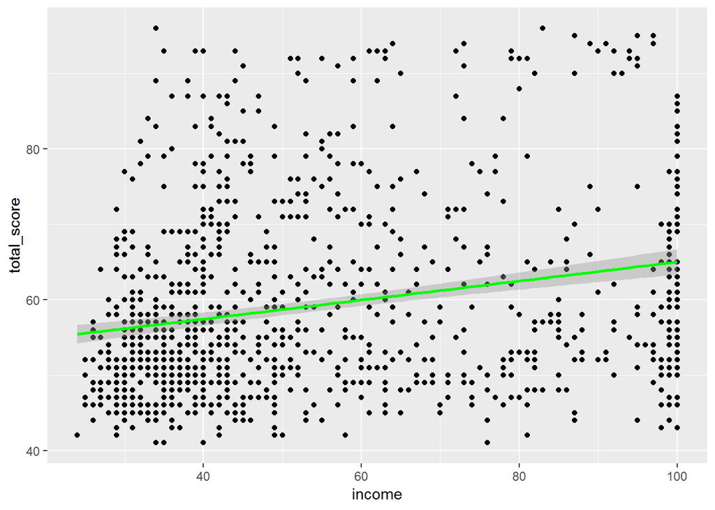

The results here are not as expected. The correlation factor is 0.226 from cor.test. It seems that not all the high ranked universities are interested in this variable. This is obvious because when we look at the dataset we can see that there are a lot of missed values in this column.

I do not know what is the reason behind this. May be ,there is no information at the organization which conducted the survey about this or the university itself is not interested in tracking this variable. Any way it seems that this variable is still not having the best effect on the rank or at least we know that universities are not interested in it.

The correlation of these two variables for the top 200 universities is 0.225 and so this correation is not biased by the rank of year 2016

## Relation between total score and students-staff ratio:

It is expected to be negative corelation. As this ratio decraese, this means better interaction and better service for the students. Let’s see.

```
##
##  Pearson's product-moment correlation
##
## data:  df$student_staff_ratio and df$total_score
## t = -9.0967, df = 1180, p-value < 2.2e-16
## alternative hypothesis: true correlation is not equal to 0
## 95 percent confidence interval:
##  -0.3085067 -0.2019190
## sample estimates:
##        cor
## -0.2559907
```

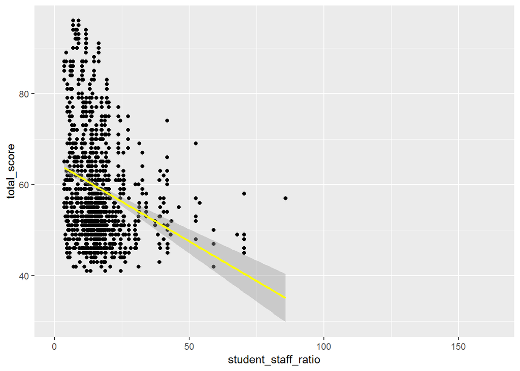

The corelation is very week and it is negative as expected , it is -0.256. I will investigate this again for the top 200 universities hoping we get stronger corrleation aswe see that ther are some outliers in this graph

```
##
##  Pearson's product-moment correlation
##
## data:  df_200$student_staff_ratio and df_200$total_score
## t = -9.0967, df = 1180, p-value < 2.2e-16
## alternative hypothesis: true correlation is not equal to 0
## 95 percent confidence interval:
##  -0.3085067 -0.2019190
## sample estimates:
##        cor
## -0.2559907
```

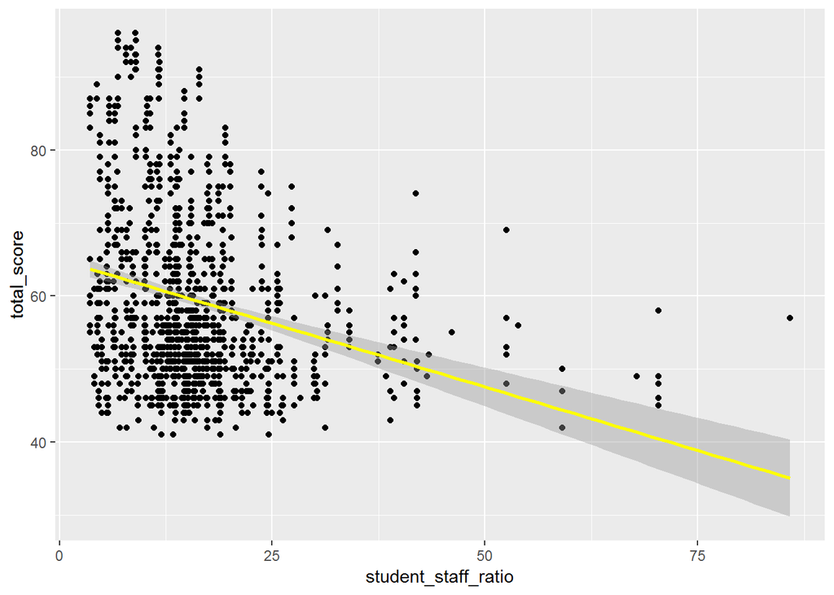

It is disappointing. It is almost the same correlation. I will again choose the top 10 universities to see what is the relation.

```
##
##  Pearson's product-moment correlation
##
## data:  df_high_rank$student_staff_ratio and df_high_rank$total_score
## t = -2.1926, df = 58, p-value = 0.03236
## alternative hypothesis: true correlation is not equal to 0
## 95 percent confidence interval:
##  -0.49576217 -0.02445955
## sample estimates:
##        cor
## -0.2766659
```

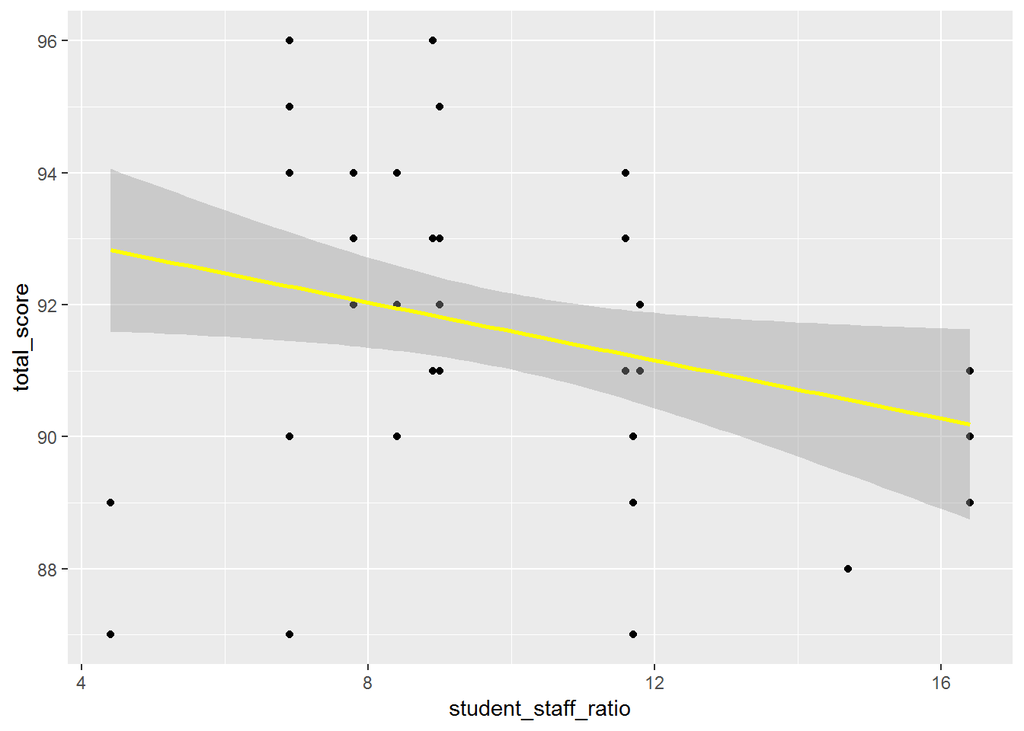

The corelation is still very week . it is only -0.276. It is un expected.

# Bivariate Analysis :

Specific parameters were chosen to conduct our analysis on. The teaching and research had a positive and strong corelation with the total score variable. However, The income had a weak correlation and the student-staff ratio had a weak and a negative correlation with the total score variable. That was unexpected.

# Multivariate Plots Section :

One good way to look at the trend of these countries over years is to look at the mean of each variable achieved by each country. Removing the missed value will not affect the calculated mean value for each variable.I will work for the whole dataset and so themean value will give us an overall indication for the education in a country.

Looking at the mean value will help us to see a clear graph with less details. However, This will give us an overall view of each of these countries over each year. We can see if a country made some improvement in one of the variables or another country lost its position in one of the variables.

From the bivariate analysis, we concluded that the two variables : teaching and research has a strong correlation with the total score. We will look at the trend of these two variables in addition to citations variable.

## Citations trend for top countries :

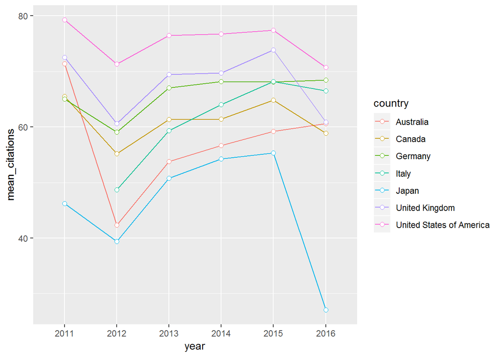

Also, There is a huge dip for Japan in 2016 and the Germany’s performance is improving to be the second one in 2016.

## Teaching trend for top countries :

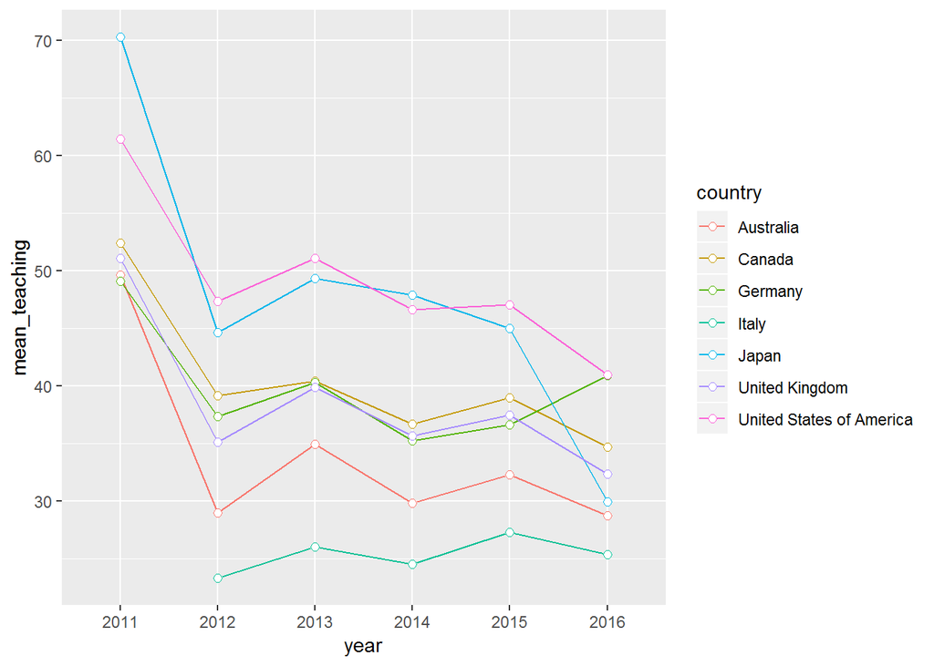

Japan had a good start at 2011 but it had a dip in 2016 again like citations. Germany again made some achivement and eventually they are equal to USA . All countries went down from 2011 to 2012 as usual. All countries wentdown from 2015 to 2016 except Germany. Good news for Germany.

## Research trend for top countries :

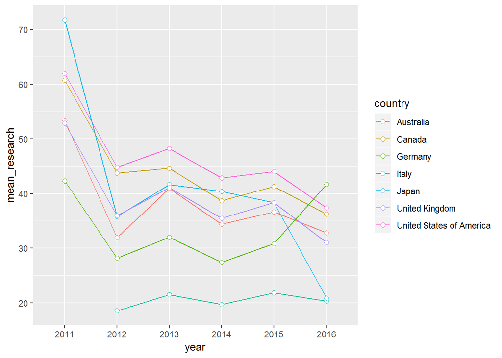

## Number of international students :

We can make multivariate analysis by getting the number of international students from the given ratio of the international students.

Then, we can plot the trend for the seleced countries over years for the total summation of international students.

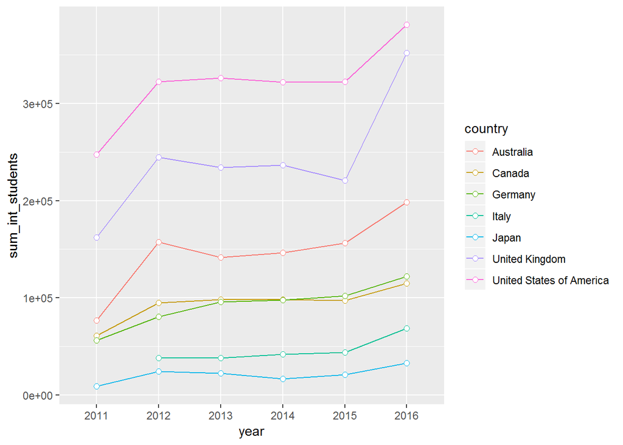

USA and UK are the leading countries in the number of international students. UK has a big jump from 2015 to 2016. Japan is the least.

# Multivariate Analysis:

The dataset contained the rank for different years and this was a good feature to look at the trend of each country. One observation is that Germany is making some improvements while Japan lost a lot although it was the leading country in 2011 for some variables.

The number of international students is very high in USA and UK. We could make better analysis if we had information about the number of scholarships for each country and also the expenses of each university.

# Final Plots and Summary :

### Plot One :

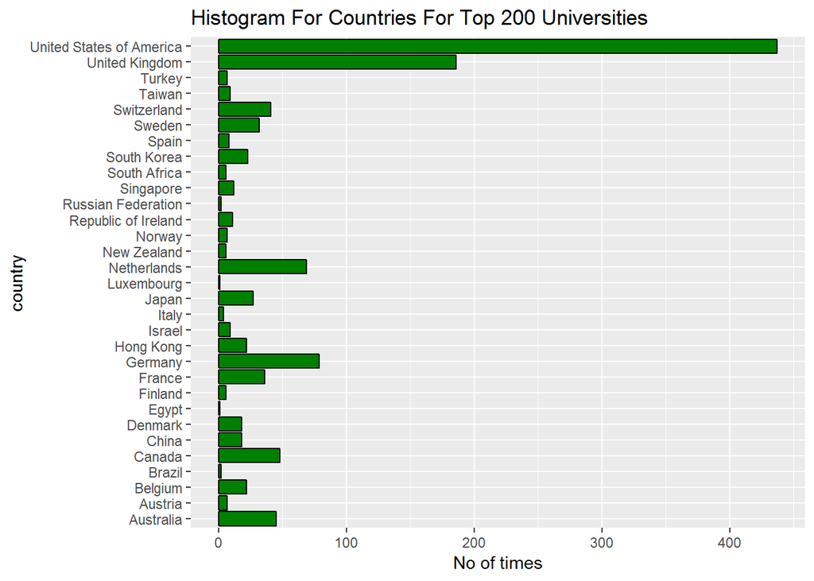

### Description One :

The first plot is a histogram to show how many times a country was stated in the 200 top ranked universities for the 6 years. This is to have an overview for the reputation for each country.

### Plot Two :

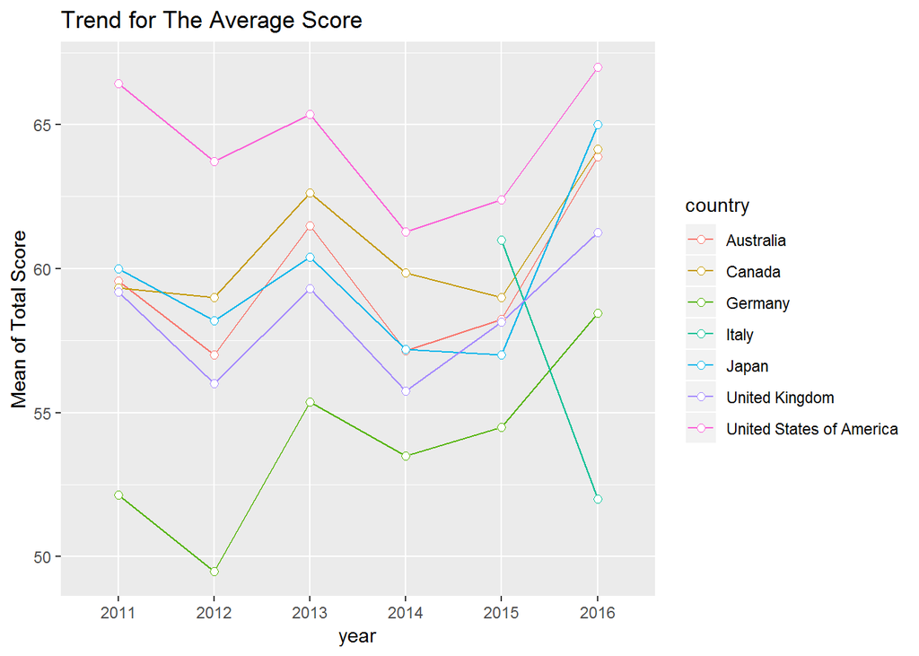

### Description Two :

The plot shows that the mean score for UK is less than Australia, Canada and Japan and this surprising for me at least. UK had a good line shape in the individual variables analyzed before but in the average total score it was less than expected . Germany also is the least country in the average mean score after Italy although it had a good rank in the individual variables.

### Plot Three

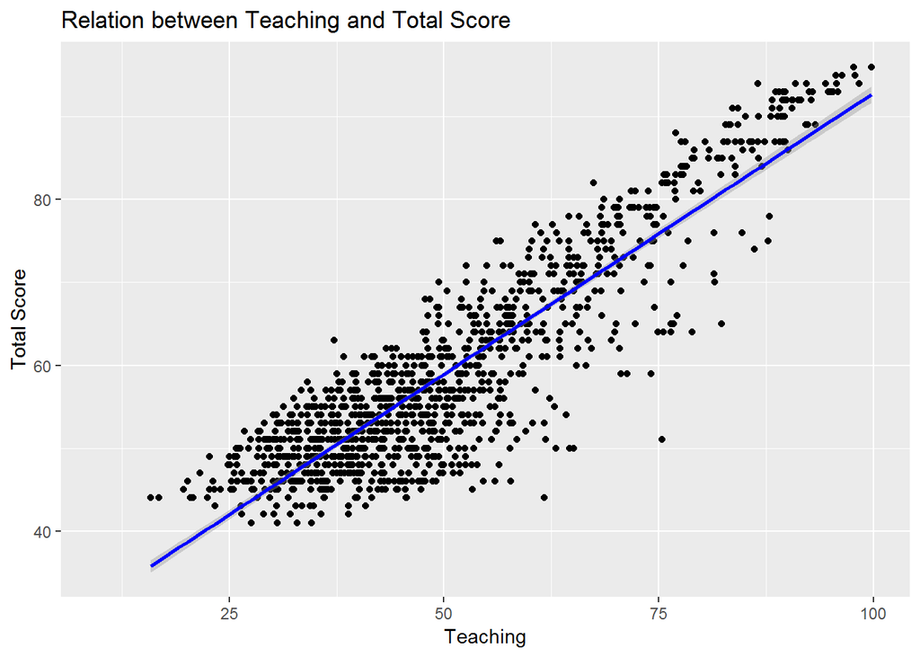

### Description Three

For me ,this is a good plot that indicates a strong relation between the teaching variable and the total score of a university. This strong relation was found also for research also .While the student staff ratio had a weak correlation with the total score of a university.

# Reflection

This was an interesting exploration through the dataset. The dataset was not so clean. Some variables were not integers and were not even clean integers. The cleaning of this dataset took some time. The dataset had a good thing which was the information repeated for 6 years and this was interesting to look at the trend of a country over the 6 years.

A future work that can be done with dataset is to fill some missed values and to add some other variables like the expenses of a university to be able to look at the relation between the expenses and the rank of the university and number of students. Also the percentage of employment can be involved also like other datasets.

A future work also is to complete investigation for other leading countries like France, Spain and Netherlands and make trends like we did for the sake of comparison.